# Monte Carlo Methods

Edward Ionides

2016-03-23

Licensed under the Creative Commons attribution-noncommercial license, http://creativecommons.org/licenses/by-nc/3.0/. Please share and remix noncommercially, mentioning its origin.

Produced in R version 3.2.3.

Objectives

1. To review some basic ideas in Monte Carlo computation and simulating random variables.
2. To provide a basic introduction to the Monte Carlo approach, and the generation of simulated random variables, for those who haven’t seen it before.

## Our context: Monte Carlo methods for POMP models.

Let’s consider a general POMP model. As before, let ${y_{1:N}^*}$ be the data, and let the model consist of a latent process $X_{0:N}$ and an observable process $Y_{1:N}$. Then the likelihood function is $\begin{eqnarray} {\mathscr{L}}(\theta) &=& f_{Y_{1:N}}({y_{1:N}^*}{\, ; \,}\theta) \\ &=&\int_{x_0}\cdots\int_{x_N}\! f_{X_0}(x_0{\, ; \,}\theta)\prod_{n=1}^{N}\!f_{Y_n|X_n}({y_n^*}{{\, | \,}}x_n{\, ; \,}\theta)\, f_{X_n|X_{n-1}}(x_n|x_{n-1}{\, ; \,}\theta)\, dx_0\dots dx_N. \end{eqnarray}$ i.e., computation of the likelihood requires integrating (or summing, for a discrete model) over all possible values of the unobserved latent process at each time point. This is very hard to do, in general.

Let’s review, and/or learn, some *Monte Carlo* approaches for evaluating this and other difficult integrals. An excellent technical reference on Monte Carlo techniques is Robert and Casella (2004).

## The fundamental theorem of Monte Carlo integration

- The basic insight of Monte Carlo methods is that we can get a numerical approximation to a challenging integral, $H = \int h(x)\, f(x)\, dx,$ if we can simulate (i.e., generate random draws) from the distribution with probability density function $f$.
- This insight is known as the *fundamental theorem of Monte Carlo integration*.

**Theorem**. Let $f(x)$ be the probability distribution function for a random variable $X$, and let $X_{1:J}=\{X_{j}, {j}=1,\dots,{J}\}$ be an independent and identically distributed sample of size ${J}$ from $f$. Let ${H_{J}}$ be the sample average of $h(X_1)\dots,h(X_{J})$, ${H_{J}} = \frac{1}{{J}}\,\sum_{{j}=1}^{{J}}\!h(X_{j}).$ Then ${H_{J}}$ converges to $H$ as ${J}\to\infty$ with probability 1. Less formally, we write ${H_{J}} \approx \int\!h(x)\,f(x)\,dx.$

**Proof**. This is the strong law of large numbers, together with the identity that ${\mathbb{E}}[h(X)] = \int\!h(x)\,f(x)\,dx.$

- We can estimate the error in this approximation, because the empirical variance $V_{J}= \frac{1}{{J}-1}\,\sum_{{j}=1}^{{J}}\!\big[h(X_{j})-H_{J}\big]^2$ approximates the true variance, ${\mathrm{Var}}[h(X)]={\mathbb{E}}\big[\big(h(X)-{\mathbb{E}}[h(X)]\big)^2\big]$.
- The standard error on the approximation $H_{{J}}\approx {\mathbb{E}}[h(X)]$ is therefore $\sqrt{\frac{V_{J}}{{J}}}.$
- From the central limit theorem, the error is approximately normally distributed: $H_{J}-{\mathbb{E}}[h(X)]\;\sim\;\mathrm{normal}\left(0,\frac{V_{J}}{{J}}\right).$
- The fundamental theorem of Monte Carlo inspires us to give further thought on how to simulate from a desired density function $f$, which may itself be a challenging problem.
- We will review simulation, but first let’s consider a useful generalization of the fundamental theorem.

## Importance sampling

- Sometimes it is difficult to sample directly from the distribution of $X$.
- In this case, we can often make use of *importance sampling*, in which we generate random samples from another distribution (easier to simulate) and make the appropriate correction.
- Specifically, suppose we wish to compute $\mathbb{E}[h(X)]$, where $X\sim{f}$, but it is difficult or impossible to draw random samples from $f$.
- Suppose $g$ is a probability distribution from which it’s relatively easy to draw samples and let $Y_{1:{J}}$ be i.i.d. random variables drawn from $g$.
- Notice that $\mathbb{E}[h(X)] = \int\!h(x)\,f(x)\,\mathrm{d}x = \int\!h(x)\,\frac{f(x)}{g(x)}\,g(x)\, dx.$
- So, we can generalize the Monte Carlo integration theorem to give the **Monte Carlo importance sampling theorem**, $\mathbb{E}[h(X)] \approx \frac{1}{{J}}\,\sum_{{j}=1}^{{J}}\!h(Y_{j})\,\frac{f(Y_{j})}{g(Y_{j})}.$
- We call $w_{j}=f(Y_{j})/g(Y_{j})$ the **importance weights**, and then we can write $\mathbb{E}[h(X)] \approx \frac{1}{{J}}\,\sum_{{j}=1}^{{J}} w_{j}\, h(Y_{j}).$
- Since ${\mathbb{E}}[w_{j}] = {\mathbb{E}}[f(Y)/g(Y)]=1$, we can modify this formula to give a **self-normalized importance sampling** estimate, $\mathbb{E}[h(X)] \approx \frac{\sum\!w_{j}\,h(Y_{j})}{\sum\!w_{j}}.$
- The self-normalized estimate requires computation of $w_{j}$ only up to a constant of proportionality.
- The Monte Carlo variance associated with this estimate is $\frac{\sum\!w_{j}\,(h(Y_{j})-\overline{h})^2}{\sum\!w_{j}}.$
- Obtaining accurate estimates requires some thought to the importance distribution $g$. Specifically, if the tails of $g$ are lighter than those of $f$, the Monte Carlo variance will be inflated and the estimates can be unusable.

## Simulation techniques for general distributions

- Simulation refers to the generation of random variables.
- The general problem of simulation is: given a probability distribution $f$, find a procedure that generates random draws from $f$.
- This is a very important problem in scientific computing and much thought and effort has gone into producing reliable simulators for many basic random variables.
- There are two basic ways of solving this problem:
  1. The transformation method,
  2. The rejection method.

### The transformation method

- This method works for discrete or continuous scalar random variables.
- Let $f$ be the probability distribution function we seek to draw from (known as the **target distribution**) and $F$ be the corresponding cumulative distribution function, i.e., $F(x) = \int_{-\infty}^x f(v)\, dv$.
- Let $F^{-1}(u) = \inf\{x: F(x)\,\ge\,u\}$ be the inverse of $F$.
- A basic fact is that, if $X\!\sim\!f$, then $F(X)\!\sim\!\mathrm{uniform}(0,1)$.  
  Proof: If $f(X)>0$, then $\begin{eqnarray} {\mathbb{P}}[F(X)\,\le\,u] &=& {\mathbb{P}}[X\,<\,F^{-1}(u)] \\ &=& F\big(F^{-1}(u)\big) = u. \end{eqnarray}$
- This suggests that, if we can compute $F^{-1}$, we use the following algorithm to generate $X\!\sim\!f$:
1. draw $U \sim \mathrm{uniform}(0,1)$.
2. let $X = F^{-1}(U)$.

### The rejection method

- The transformation method is very efficient in that we are guaranteed to obtain a valid $X$ from the density $f$ for every $U \sim \mathrm{uniform}(0,1)$ we generate.
- Sometimes, however, we cannot compute the inverse of the cumulative distribution function, as required by the transformation method.
- Under such circumstances, the rejection method offers a less efficient, but more flexible, alternative.
- We’ll see how and why this method works.

#### The rejection method for uniform random variables on arbitrary sets

- Let a random variable $X$ take values in ${\mathbb{R}}^{{\mathrm{dim}(X)}}$.
- Suppose that $X$ is **uniformly distributed** over a region $D\subset {\mathbb{R}}^{{\mathrm{dim}(X)}}$. This means that, for any ${A}\subset{D}$, ${\mathbb{P}}[X\in{A]}=\frac{\mathrm{area}(A)}{\mathrm{area}(D)}.$ We write $X \sim \mathrm{uniform}(D).$
- Let’s suppose that we wish to simulate $X\!\sim\!\mathrm{uniform}(D)$.
- Suppose that we don’t know how to directly simulate a random draw from $D$, but we know $D$ is a subset of some nicer region $U\subset {\mathbb{R}}^{{\mathrm{dim}(X)}}$.
- If we know how to generate $Y\!\sim\!\mathrm{uniform}(U)$, then we can simply do so until ${Y}\in{D}$, at which point we take $X=Y$.
- Since for any $A\subset{D}$, $\begin{eqnarray} {\mathbb{P}}[X\in A] &=& {\mathbb{P}}[Y\in A |Y\in D] \\ &=& \frac{\mathrm{area}(A)}{\mathrm{area}(U)}\Big{/}\frac{\mathrm{area}(D)}{\mathrm{area}(U)} \\ &=& \frac{\mathrm{area}(A)}{\mathrm{area}(D)}, \end{eqnarray}$ it follows that $Y\!\sim\!\mathrm{uniform}(D)$.
- Consider an analogy to throwing darts. If the darts are thrown in such a way as to be equally likely to land anywhere in $U$, then those that do land in $D$ are equally likely to land anywhere in $D$.

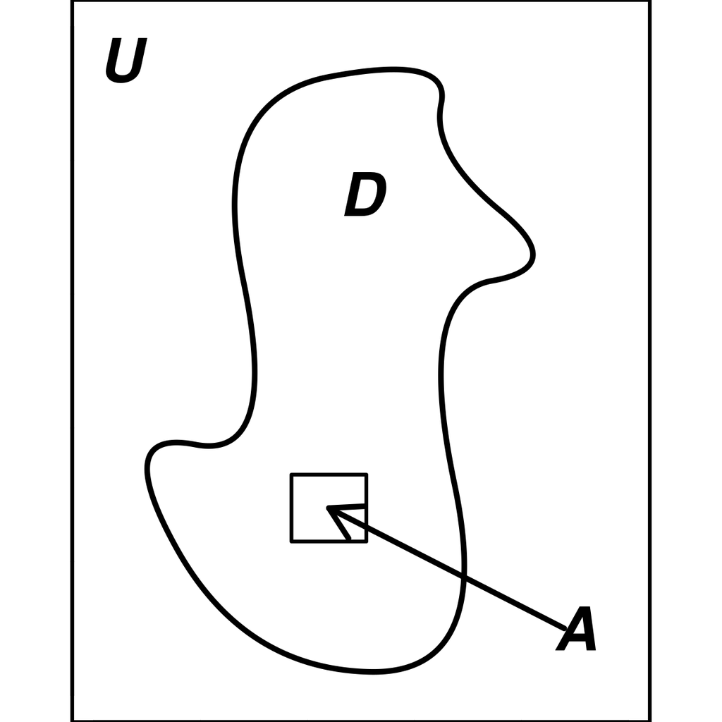

#### The rejection method for dominated densities

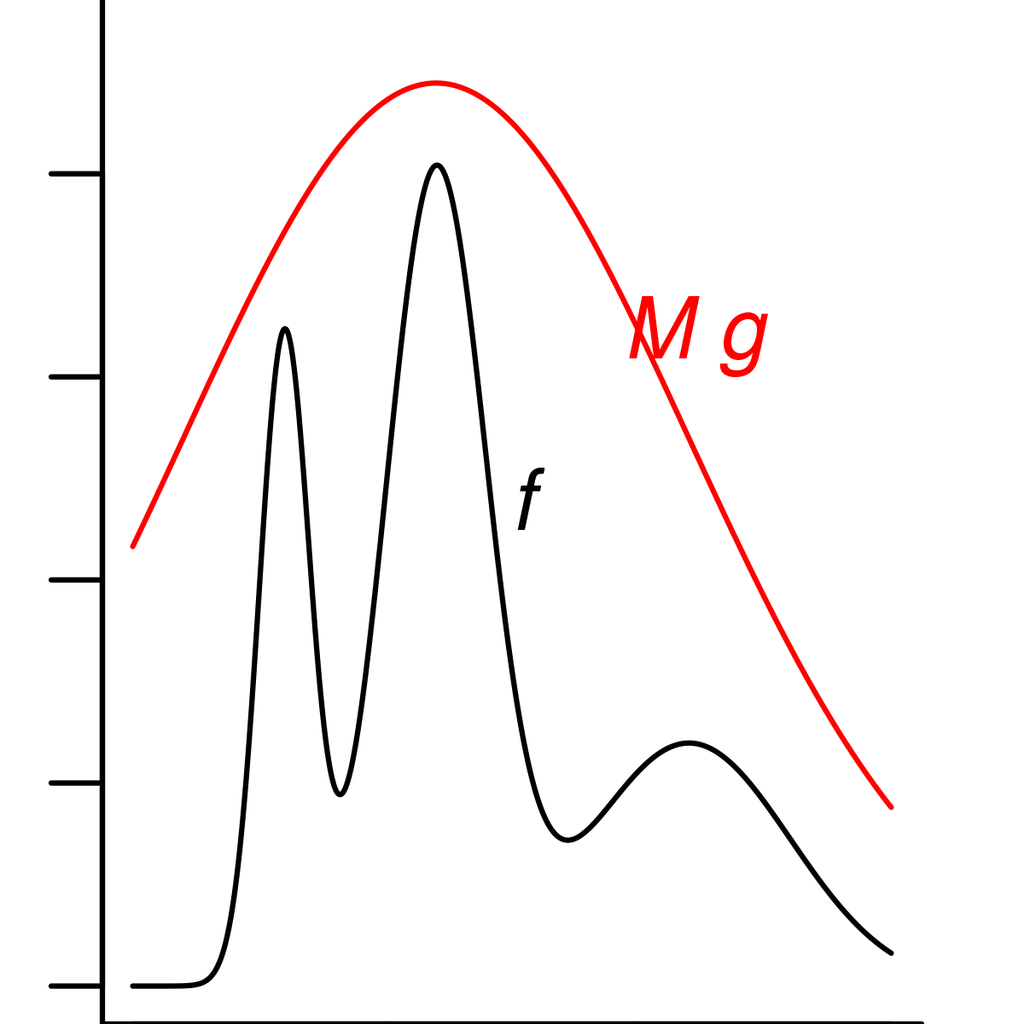

#### Acknowledgement: These notes derive from [notes by Aaron King](http://kingaa.github.io/sbied/pfilter/monteCarlo.html).

References

Robert, C. P., and G. Casella. 2004. Monte Carlo Statistical Methods. 2nd editions. Springer-Verlag.